# Trabalho 1 - Projeto de Banco de Dados

## Q3

> **Tempo sem índice:** De 3,9s a 6s

> **Tempo com índice:** 4,9s

> Pelo fato da tabela **ORDERS** não ter nenhum índice, o óbvio foi criar o seguinte índice:

```sql
create index idx_order_conditions on ORDERS(o_custkey, o_orderkey, o_orderdate);
```

> Ele diminuiu o *QUERY COST* mas não houve melhora no tempo. Em alguns casos a consulta sem índice chegou a rodar mais rápido
- **Execution plain sem índice**

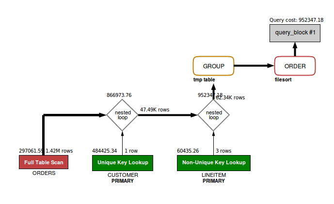

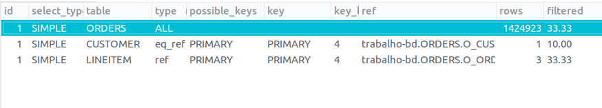

- **Execution Plan com índice criado**

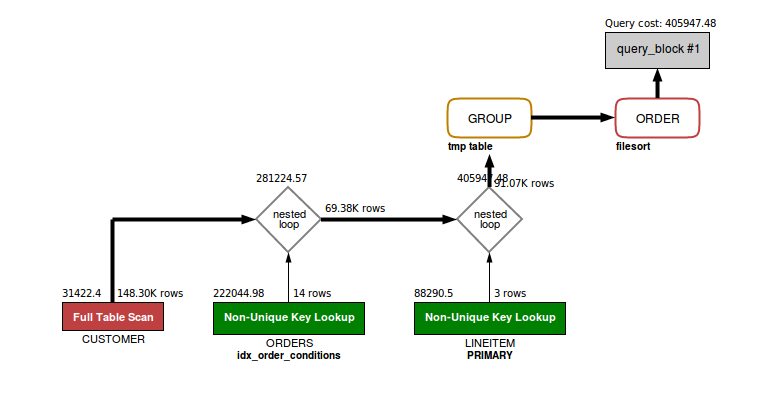

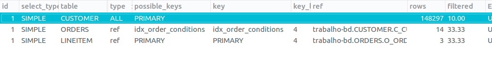

## Q4

> **Tempo sem índice:** 2,5s

> **Tempo com índice:** 1,5s

> Novamente uma consulta na tabela **ORDERS** Pelo fato de não possuir índices, escolhemos o seguinte:

```sql
create index idx_order_orderdate on ORDERS(o_orderdate);
```

> O índice diminuiu o *QUERY COST* e também o tempo da consulta
- **Execution plain sem índice**

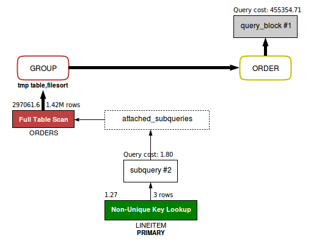

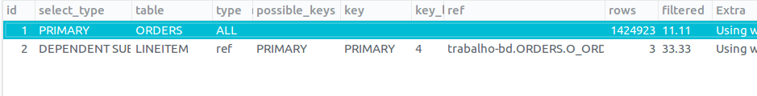

- **Execution Plan com índice criado**

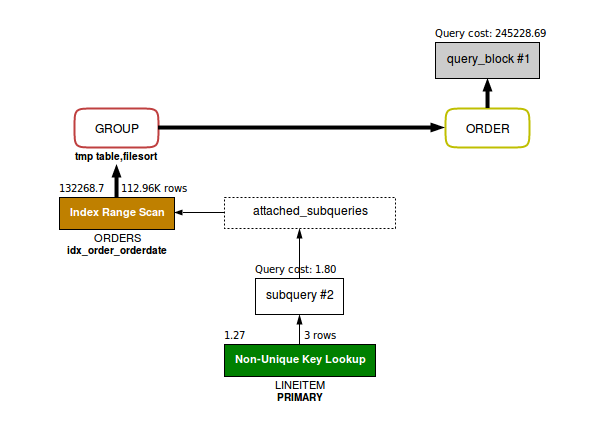

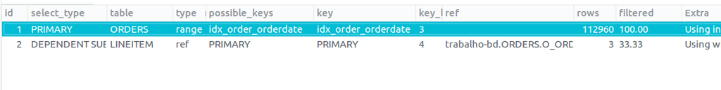